# (prosper Loan Data)

```
    by (Ahmed Aredah)
```

## Project Describtion

### Data Set

> This data set contains 113,937 loans with 81 variables on each loan, including loan amount, borrower rate (or interest rate), current loan status, borrower income, and many others.

### Project Output

In this explanatory study, we tend to study and address the following questions:

> What factors affect a loan’s outcome status?

> What affects the borrower’s APR or interest rate?

> Are there differences between loans depending on how large the original loan amount was?

## Preliminary Wrangling

```python
# import all packages and set plots to be embedded inline
import numpy as np
import pandas as pd
import matplotlib.pyplot as plt
import seaborn as sb
import math

%matplotlib inline
```

```python
# Load Dataset
df = pd.read_csv('data/prosperLoanData.csv')
```

### Dataset Structure

```python
# Shape of the dataframe
df.shape
```

```
(113937, 81)
```

> **The dataframe has 113937 rows and 81 columns**

```python
# Dataframe Column names
df.columns
```

```
Index(['ListingKey', 'ListingNumber', 'ListingCreationDate', 'CreditGrade',
       'Term', 'LoanStatus', 'ClosedDate', 'BorrowerAPR', 'BorrowerRate',
       'LenderYield', 'EstimatedEffectiveYield', 'EstimatedLoss',
       'EstimatedReturn', 'ProsperRating (numeric)', 'ProsperRating (Alpha)',
       'ProsperScore', 'ListingCategory (numeric)', 'BorrowerState',
       'Occupation', 'EmploymentStatus', 'EmploymentStatusDuration',
       'IsBorrowerHomeowner', 'CurrentlyInGroup', 'GroupKey',
       'DateCreditPulled', 'CreditScoreRangeLower', 'CreditScoreRangeUpper',
       'FirstRecordedCreditLine', 'CurrentCreditLines', 'OpenCreditLines',
       'TotalCreditLinespast7years', 'OpenRevolvingAccounts',
       'OpenRevolvingMonthlyPayment', 'InquiriesLast6Months', 'TotalInquiries',
       'CurrentDelinquencies', 'AmountDelinquent', 'DelinquenciesLast7Years',
       'PublicRecordsLast10Years', 'PublicRecordsLast12Months',
       'RevolvingCreditBalance', 'BankcardUtilization',
       'AvailableBankcardCredit', 'TotalTrades',
       'TradesNeverDelinquent (percentage)', 'TradesOpenedLast6Months',
       'DebtToIncomeRatio', 'IncomeRange', 'IncomeVerifiable',
       'StatedMonthlyIncome', 'LoanKey', 'TotalProsperLoans',
       'TotalProsperPaymentsBilled', 'OnTimeProsperPayments',
       'ProsperPaymentsLessThanOneMonthLate',
       'ProsperPaymentsOneMonthPlusLate', 'ProsperPrincipalBorrowed',
       'ProsperPrincipalOutstanding', 'ScorexChangeAtTimeOfListing',
       'LoanCurrentDaysDelinquent', 'LoanFirstDefaultedCycleNumber',
       'LoanMonthsSinceOrigination', 'LoanNumber', 'LoanOriginalAmount',
       'LoanOriginationDate', 'LoanOriginationQuarter', 'MemberKey',
       'MonthlyLoanPayment', 'LP_CustomerPayments',
       'LP_CustomerPrincipalPayments', 'LP_InterestandFees', 'LP_ServiceFees',
       'LP_CollectionFees', 'LP_GrossPrincipalLoss', 'LP_NetPrincipalLoss',
       'LP_NonPrincipalRecoverypayments', 'PercentFunded', 'Recommendations',
       'InvestmentFromFriendsCount', 'InvestmentFromFriendsAmount',
       'Investors'],
      dtype='object')
```

### The main feature(s) of interest in the dataset

> **The main features are features that are causing AmountDelinquent to increase or the LoanStatus to be Past Due.**

### Features of interest investigation

> **The features of interest are the ones affecting either AmountDelinquent and LoadStatus**

```python
# Show only 2 rows of the data for verification
df.head(2)
```

|  | ListingKey | ListingNumber | ListingCreationDate | CreditGrade | Term | LoanStatus | ClosedDate | BorrowerAPR | BorrowerRate | LenderYield | ... | LP_ServiceFees | LP_CollectionFees | LP_GrossPrincipalLoss | LP_NetPrincipalLoss | LP_NonPrincipalRecoverypayments | PercentFunded | Recommendations | InvestmentFromFriendsCount | InvestmentFromFriendsAmount | Investors |
| --- | --- | --- | --- | --- | --- | --- | --- | --- | --- | --- | --- | --- | --- | --- | --- | --- | --- | --- | --- | --- | --- |
| 0 | 1021339766868145413AB3B | 193129 | 2007-08-26 19:09:29.263000000 | C | 36 | Completed | 2009-08-14 00:00:00 | 0.16516 | 0.158 | 0.138 | ... | -133.18 | 0.0 | 0.0 | 0.0 | 0.0 | 1.0 | 0 | 0 | 0.0 | 258 |
| 1 | 10273602499503308B223C1 | 1209647 | 2014-02-27 08:28:07.900000000 | NaN | 36 | Current | NaN | 0.12016 | 0.092 | 0.082 | ... | 0.00 | 0.0 | 0.0 | 0.0 | 0.0 | 1.0 | 0 | 0 | 0.0 | 1 |

2 rows × 81 columns

```python
# Get the number of non-null values and their data type
df.isna().sum()
```

```
ListingKey                         0
ListingNumber                      0
ListingCreationDate                0
CreditGrade                    84984
Term                               0
                               ...
PercentFunded                      0
Recommendations                    0
InvestmentFromFriendsCount         0
InvestmentFromFriendsAmount        0
Investors                          0
Length: 81, dtype: int64
```

```python
# Drop all NA values in all columns
df.dropna(inplace = True, subset = ['DebtToIncomeRatio', 'EmploymentStatusDuration'])
```

```python
# Quickly check the non-null number
df.info()
```

```
<class 'pandas.core.frame.DataFrame'>
Int64Index: 97888 entries, 0 to 113936
Data columns (total 81 columns):
 #   Column                               Non-Null Count  Dtype
---  ------                               --------------  -----
 0   ListingKey                           97888 non-null  object
 1   ListingNumber                        97888 non-null  int64
 2   ListingCreationDate                  97888 non-null  object
 3   CreditGrade                          20225 non-null  object
 4   Term                                 97888 non-null  int64
 5   LoanStatus                           97888 non-null  object
 6   ClosedDate                           43374 non-null  object
 7   BorrowerAPR                          97888 non-null  float64
 8   BorrowerRate                         97888 non-null  float64
 9   LenderYield                          97888 non-null  float64
```

[output cut: 73 more lines]

```python
# Get a quick describtion about the numeric values in the dataset
df.describe()
```

|  | ListingNumber | Term | BorrowerAPR | BorrowerRate | LenderYield | EstimatedEffectiveYield | EstimatedLoss | EstimatedReturn | ProsperRating (numeric) | ProsperScore | ... | LP_ServiceFees | LP_CollectionFees | LP_GrossPrincipalLoss | LP_NetPrincipalLoss | LP_NonPrincipalRecoverypayments | PercentFunded | Recommendations | InvestmentFromFriendsCount | InvestmentFromFriendsAmount | Investors |
| --- | --- | --- | --- | --- | --- | --- | --- | --- | --- | --- | --- | --- | --- | --- | --- | --- | --- | --- | --- | --- | --- |
| count | 9.788800e+04 | 97888.000000 | 97888.000000 | 97888.000000 | 97888.000000 | 77543.000000 | 77543.000000 | 77543.000000 | 77543.000000 | 77543.000000 | ... | 97888.000000 | 97888.00000 | 97888.000000 | 97888.000000 | 97888.000000 | 97888.000000 | 97888.000000 | 97888.000000 | 97888.000000 | 97888.00000 |
| mean | 6.694114e+05 | 41.326741 | 0.217561 | 0.190677 | 0.180542 | 0.166606 | 0.078594 | 0.095287 | 4.131837 | 6.062030 | ... | -57.391999 | -13.75275 | 628.697348 | 610.383033 | 23.844409 | 0.998545 | 0.049373 | 0.023180 | 15.405873 | 82.77321 |
| std | 3.023032e+05 | 10.775959 | 0.080074 | 0.074465 | 0.074215 | 0.067387 | 0.045937 | 0.029893 | 1.658758 | 2.362402 | ... | 62.227907 | 109.23522 | 2302.554687 | 2270.307400 | 271.439132 | 0.018169 | 0.313497 | 0.210912 | 270.862856 | 106.91461 |
| min | 9.827900e+04 | 12.000000 | 0.006530 | 0.000000 | -0.010000 | -0.181600 | 0.004900 | -0.181600 | 1.000000 | 1.000000 | ... | -664.870000 | -9274.75000 | -94.200000 | -954.550000 | 0.000000 | 0.700000 | 0.000000 | 0.000000 | 0.000000 | 1.00000 |
| 25% | 4.621932e+05 | 36.000000 | 0.155380 | 0.131400 | 0.121400 | 0.115000 | 0.042400 | 0.074080 | 3.000000 | 4.000000 | ... | -78.242500 | 0.00000 | 0.000000 | 0.000000 | 0.000000 | 1.000000 | 0.000000 | 0.000000 | 0.000000 | 1.00000 |
| 50% | 6.298090e+05 | 36.000000 | 0.207350 | 0.180000 | 0.170000 | 0.157600 | 0.069900 | 0.090600 | 4.000000 | 6.000000 | ... | -37.030000 | 0.00000 | 0.000000 | 0.000000 | 0.000000 | 1.000000 | 0.000000 | 0.000000 | 0.000000 | 44.00000 |
| 75% | 9.213135e+05 | 36.000000 | 0.280320 | 0.249200 | 0.239200 | 0.217000 | 0.108000 | 0.115000 | 5.000000 | 8.000000 | ... | -15.430000 | 0.00000 | 0.000000 | 0.000000 | 0.000000 | 1.000000 | 0.000000 | 0.000000 | 0.000000 | 120.00000 |
| max | 1.255149e+06 | 60.000000 | 0.423950 | 0.360000 | 0.340000 | 0.319900 | 0.366000 | 0.266700 | 7.000000 | 11.000000 | ... | 32.060000 | 0.00000 | 25000.000000 | 25000.000000 | 21117.900000 | 1.012500 | 24.000000 | 20.000000 | 25000.000000 | 1189.00000 |

8 rows × 61 columns

## Univariate Exploration

> In this section, investigate distributions of individual variables. If you see unusual points or outliers, take a deeper look to clean things up and prepare yourself to look at relationships between variables.

```python
# Get the unique values of Loan Status
df.LoanStatus.unique()
# Past Due values have another attribute attached to it.
```

```
array(['Completed', 'Current', 'Past Due (1-15 days)', 'Defaulted',
       'Chargedoff', 'Past Due (16-30 days)', 'Past Due (61-90 days)',
       'Past Due (31-60 days)', 'Past Due (91-120 days)',
       'FinalPaymentInProgress', 'Past Due (>120 days)', 'Cancelled'],
      dtype=object)
```

```python
#Split the LoanStatus Column to get only the Status
df[['LoanStatus2','LoanStatusPastDue']]= df.LoanStatus.str.split('(',expand=True,);
```

```python
#Remove ')' from the last column LoanStatusPastDue
df['LoanStatusPastDue'] = df['LoanStatusPastDue'].str.replace(')', '')
```

```python
# map category names instead of numeric categories
df['ListingCategory'] = df['ListingCategory (numeric)'].map({0: 'Not Available', 1: 'Debt Consolidation', 2 : 'Home Improvement', 3: 'Business' , 4 : 'Personal Loan' , 5 : 'Student Use' , 6 : 'Auto' , 7 : 'Other' , 8 : 'Baby&Adoption' , 9 : 'Boat' , 10 : 'Cosmetic Procedure' , 11 : 'Engagement Ring' , 12 : 'Green Loans' , 13 : 'Household Expenses' , 14 : 'Large Purchases' , 15 : 'Medical/Dental' , 16 : 'Motorcycle' , 17 : 'RV' , 18 : 'Taxes' , 19 : 'Vacation' , 20 : 'Wedding Loans'}).fillna(df['ListingCategory (numeric)'])
```

```python
# Convert days to years
def get_years_from_days(x, inverse = False):
    if x > 0:
        if not inverse:
            return x/360
        else:
            return x*360

# Convert Months to years
def get_years_from_months(x, inverse = False):
    if x > 0:
        if not inverse:
            return x/12
        else:
            return x*12

# Convert values to log10
def apply_log10(x, inverse = False):
    if not inverse:
        return math.log(x,10)
    else:
        return 10**x

# Convert Values to log
def apply_log(x, inverse = False):
    if not inverse:
        return np.log(x)
    else:
        return np.exp(x)

#Convert values to 1/x
def div_inverse(x):
    if x == 0:
        return 0
    else:
        return 1/x
```

```python
df.IncomeRange.unique()
```

```
array(['$25,000-49,999', '$50,000-74,999', '$100,000+', '$75,000-99,999',
       '$1-24,999', 'Not employed', 'Not displayed'], dtype=object)
```

```python
IncomeRangeCategories = ['Not displayed','Not employed', '$1-24,999', '$25,000-49,999', '$50,000-74,999', '$75,000-99,999', '$100,000+']
IncomeRangeTypes = pd.api.types.CategoricalDtype(categories = IncomeRangeCategories, ordered = True)
df['IncomeRange'] = df['IncomeRange'].astype(IncomeRangeTypes)
```

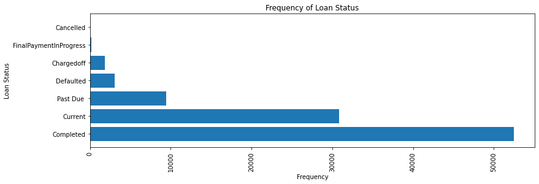

```python
# Enlarge the figure size
plt.figure(figsize = [13,4]);

# Histogram of Loan Status
# plt.subplot(5,2,1)
plt.barh(df.LoanStatus2.unique(), df.LoanStatus2.value_counts());
plt.title('Frequency of Loan Status');
plt.ylabel('Loan Status');
plt.xlabel('Frequency');
plt.xticks(rotation = 90);
```

[figure not shown]

```python
# Enlarge the figure size
plt.figure(figsize = [15,20]);

#Histogram of Loan Borrow Employement Statment
plt.subplot(5,2,2)
plt.barh(df.EmploymentStatus.unique(), df.EmploymentStatus.value_counts());
plt.title('Frequency of Loan Borrower Employement Status');
plt.ylabel('Employment Status');
plt.xlabel('Frequency');
plt.xticks(rotation = 90);
```

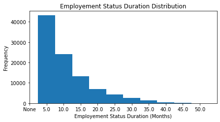

```python
# Enlarge the figure size
plt.figure(figsize = [15,20]);
plt.subplot(5,2,8);
bins = np.arange(0,55, 5);
plt.hist(df.EmploymentStatusDuration.apply(get_years_from_months), bins = bins);
plt.xticks(bins-2.5, ['{}'.format(x) for x in (get_years_from_months(y) for y in (bins*12))]);
plt.title('Employement Status Duration Distribution');
plt.xlabel('Employement Status Duration (Months)');
plt.ylabel('Frequency');
```

The most frequent Duration for the current employement status is 5 years.

Higher numbers are also available but with very low rate.

More investigation on Employement Status and Duratio is needed

[figure not shown]

```python
# Enlarge the figure size
plt.figure(figsize = [15,25]);

#Histogram of Loan Categories
plt.subplot(5,2,3)
df[df['ListingCategory'] != 'Not Available']
plt.barh(df[df['ListingCategory'] != 'Not Available'].ListingCategory.unique(), df[df['ListingCategory'] != 'Not Available'].ListingCategory.value_counts());
plt.title('Frequency of Loan Categories');
plt.ylabel('Loan Categories');
plt.xlabel('Frequency');
plt.xticks(rotation = 90);
```

Debt Consolidation is among the most frequent category after the home improvement

Debt Consolidation means they failed to pay off a past loan, that means they may tend to not pay again

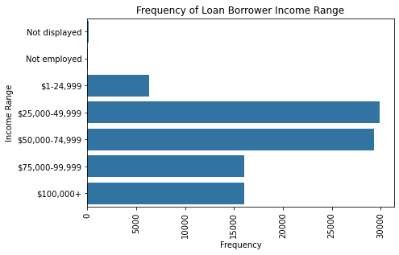

```python
# Enlarge the figure size
plt.figure(figsize = [15,25]);


#Histogram of Borrowers Income Range
plt.subplot(5,2,4)
sb.countplot(y = df.IncomeRange, color = sb.color_palette()[0]);
plt.title('Frequency of Loan Borrower Income Range');
plt.ylabel('Income Range');
plt.xlabel('Frequency');
plt.xticks(rotation = 90);
```

The most frequent Borrower Income Range is the mid range.

Higher Income Range are also available with lower frequency than the mid range

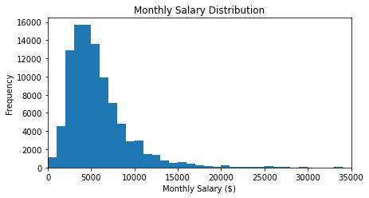

```python
# Enlarge the figure size
plt.figure(figsize = [15,20]);

#Histogram of Borrowers Monthly Salary
plt.subplot(5,2,5);
xticks = np.arange(0,df.StatedMonthlyIncome.max(), 1000);
plt.hist(df.StatedMonthlyIncome, bins = xticks);
plt.xlim(0,35000);
plt.title('Monthly Salary Distribution');
plt.xlabel('Monthly Salary ($)');
plt.ylabel('Frequency');
```

Monthly distribution is skewed to the right

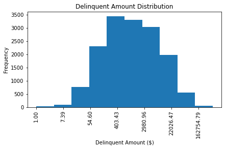

```python
# Enlarge the figure size
plt.figure(figsize = [15,20]);

temp = df[df['AmountDelinquent']!=0].AmountDelinquent.apply(apply_log)
#Histogram of Delinquent Amount
plt.subplot(5,2,6);
# xticks = np.arange(0,6000, 50);, bins = xticks
plt.hist(temp)
xticks = [0,2,4,6,8,10,12]
xlabels = ['{:.2f}'.format(x) for x in (apply_log(y, True) for y in xticks)]
plt.xticks(xticks,xlabels, rotation = 90)

plt.title('Delinquent Amount Distribution');
plt.xlabel('Delinquent Amount ($)');
plt.ylabel('Frequency');
```

Delinquent Amount distribution is skewed to the right

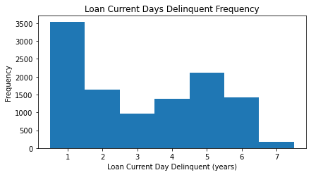

```python
# Enlarge the figure size
plt.figure(figsize = [15,20]);

#Histogram of Delinuent Days
plt.subplot(5,2,9);
bins = np.arange(0,8,1);
plt.hist(df['LoanCurrentDaysDelinquent'].apply(get_years_from_days), bins = bins+0.5);
plt.title('Loan Current Days Delinquent Frequency');
plt.xlabel('Loan Current Day Delinquent (years)');
plt.ylabel('Frequency');
```

There is a big portion of borrowers tend to not pay back the loan until 5 years.

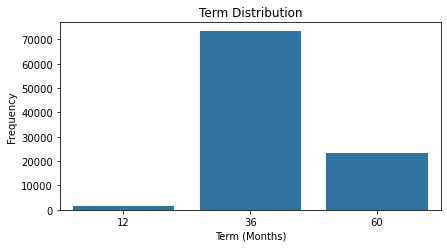

```python
# Enlarge the figure size
plt.figure(figsize = [15,20]);

#Histogram of Term
plt.subplot(5,2,6)
sb.countplot(df.Term, color = sb.color_palette()[0]);
plt.title('Term Distribution');
plt.xlabel('Term (Months)');
plt.ylabel('Frequency');
```

The most frequent term is 36 months.

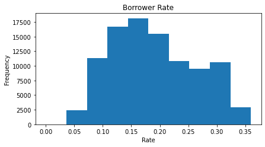

```python
# Enlarge the figure size
plt.figure(figsize = [15,20]);


plt.subplot(5,2,10);
plt.hist(df.BorrowerRate);
plt.title('Borrower Rate');
plt.xlabel('Rate');
plt.ylabel('Frequency');
```

The most frequent borrower rate is 15%

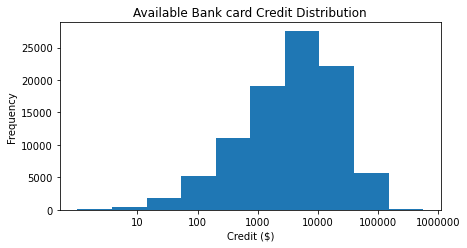

```python
# Enlarge the figure size
plt.figure(figsize = [15,20]);

temp = df[df.AvailableBankcardCredit!=0].AvailableBankcardCredit.apply(apply_log10)

plt.subplot(5,2,10);
plt.hist(temp);
xticks = [1,2,3,4,5,6]
xlabels = ['{}'.format(x) for x in (apply_log10(y, True) for y in xticks)]
plt.xticks(xticks,xlabels)
plt.title('Available Bank card Credit Distribution');
plt.xlabel('Credit ($)');
plt.ylabel('Frequency');
```

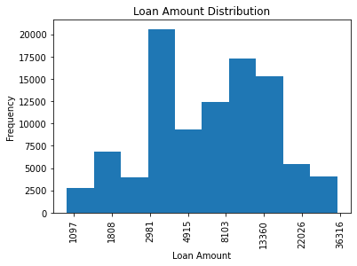

```python
plt.hist(df.LoanOriginalAmount.apply(apply_log));
xticks = [7,7.5,8,8.5,9,9.5,10,10.5];
plt.xticks(xticks, ['{:.0f}'.format(xx) for xx in (apply_log(x, True) for x in xticks)], rotation = 90);

plt.title('Loan Amount Distribution')
plt.xlabel('Loan Amount')
plt.ylabel('Frequency')
```

Loan Amount is bimodal around 3K and 13K.

### Tidness of the data

> Some Variables distributions are very skewed to the left/right. Log/log10 are applied in such cases

## Bivariate Exploration

> Visualize all relationships in the dataframe

```python
# #Explore all numeric variables
#Do not run this code ... It takes 2 hpurs to finish
# numeric_columns = df.select_dtypes(include=['float64', 'int64']).columns.tolist()
# g = sb.PairGrid(data = df, vars = numeric_columns)
# g.map_diag(plt.hist)
# g.map_offdiag(plt.scatter)
```

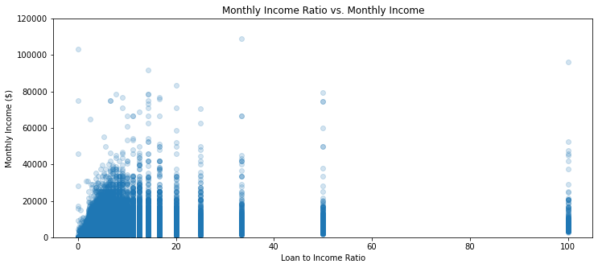

```python
#Plot Monthly Income Ration to Monthly Income
plt.figure(figsize = [12,5])
plt.scatter(x = df.DebtToIncomeRatio.apply(div_inverse), y = df.StatedMonthlyIncome, alpha = 0.2);
plt.ylim(0,120000);
plt.xlabel('Loan to Income Ratio');
plt.ylabel('Monthly Income ($)');
plt.title('Monthly Income Ratio vs. Monthly Income');
```

> To better understand what forces borrowers from not paying loans back. we need to filter only The number of days delinquent that is more than a year.

```python
# Get dataset of late payments
df_late = df[df['LoanCurrentDaysDelinquent'].apply(get_years_from_days)>1]
```

```python
# #Explore all numeric variables
# # Do not run this code ... It takes 2 hpurs to finish

# numeric_columns = df_late.select_dtypes(include=['float64']).columns.tolist()
# g = sb.PairGrid(data = df_late, vars = numeric_columns)
# g.map_diag(plt.hist)
# g.map_offdiag(plt.scatter)
```

```python
df_late['MonthlyLoanPaymentDividedByMonthlyIncome'] = df_late['MonthlyLoanPayment'] / df_late['StatedMonthlyIncome']
```

```python
df['MonthlyLoanPaymentDividedByMonthlyIncome'] = df['MonthlyLoanPayment'] / df['StatedMonthlyIncome']
```

```python
# Describe late payments Dataset
df_late['MonthlyLoanPaymentDividedByMonthlyIncome'].describe()
```

```
count     9130.000000
mean        42.455265
std        563.881583
min          0.000000
25%          0.028120
50%          0.047524
75%          0.081431
max      12571.730287
Name: MonthlyLoanPaymentDividedByMonthlyIncome, dtype: float64
```

```python
# Get only dataset of non zero values of Monthly Loan Payment and category of not (NOt Available)
temp_df = df_late[(df_late.MonthlyLoanPaymentDividedByMonthlyIncome > 0) &
                  (df_late.ListingCategory != 'Not Available')]
```

### Interesting Relationships

> Borrower Interest rate is directly correlated to the following:

> Lend Yield

> Estimated Effective Yield

> Estimated Loss

> Estimated Return

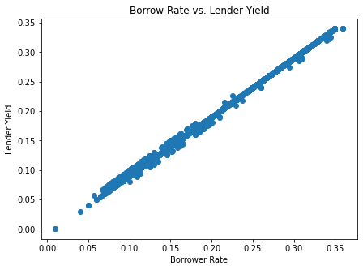

```python
# Plot Borrower Interest rate to Lend Yield
plt.figure(figsize=[7,5])
plt.scatter(x = temp_df.BorrowerRate, y= temp_df.LenderYield)
plt.xlabel('Borrower Rate')
plt.ylabel('Lender Yield')
plt.title('Borrow Rate vs. Lender Yield')
```

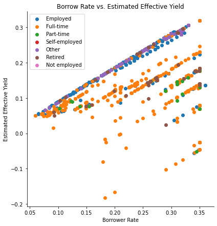

```python
# Plot Borrower Interest rate to Lend Yield
plt.figure(figsize=[10,7])

g = sb.FacetGrid(data = temp_df, hue = 'EmploymentStatus', height = 6);
g.map(plt.scatter, 'BorrowerRate', 'EstimatedEffectiveYield');
plt.legend(loc = 'upper left');
plt.xlabel('Borrower Rate');
plt.ylabel('Estimated Effective Yield');
plt.title('Borrow Rate vs. Estimated Effective Yield');
```

> Employment Status seems to be affecting the estimated effective yield.

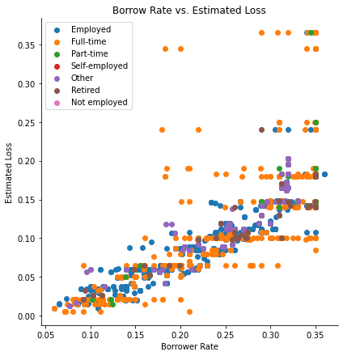

```python
# Plot Borrower Interest rate to Lend Yield
plt.figure(figsize=[10,7])

g = sb.FacetGrid(data = temp_df, hue = 'EmploymentStatus', height = 6)
g.map(plt.scatter, 'BorrowerRate', 'EstimatedLoss')


# Plot Borrower Interest rate to Estimated Loss
plt.legend(loc = 'upper left')
plt.xlabel('Borrower Rate')
plt.ylabel('Estimated Loss')
plt.title('Borrow Rate vs. Estimated Loss')
```

> The estimated loss seems to be not affected by the employment status

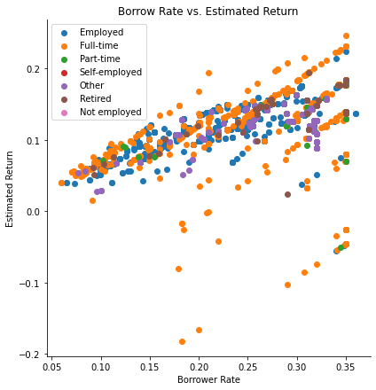

```python
# Plot Borrower Interest rate to Lend Yield
plt.figure(figsize=[10,7]);

# Plot Borrower Interest rate to Estimated Return
g = sb.FacetGrid(data = temp_df, hue = 'EmploymentStatus', height = 6);
g.map(plt.scatter, 'BorrowerRate', 'EstimatedReturn');
plt.legend(loc = 'upper left');
plt.xlabel('Borrower Rate');
plt.ylabel('Estimated Return');
plt.title('Borrow Rate vs. Estimated Return');
```

## Multivariate Exploration

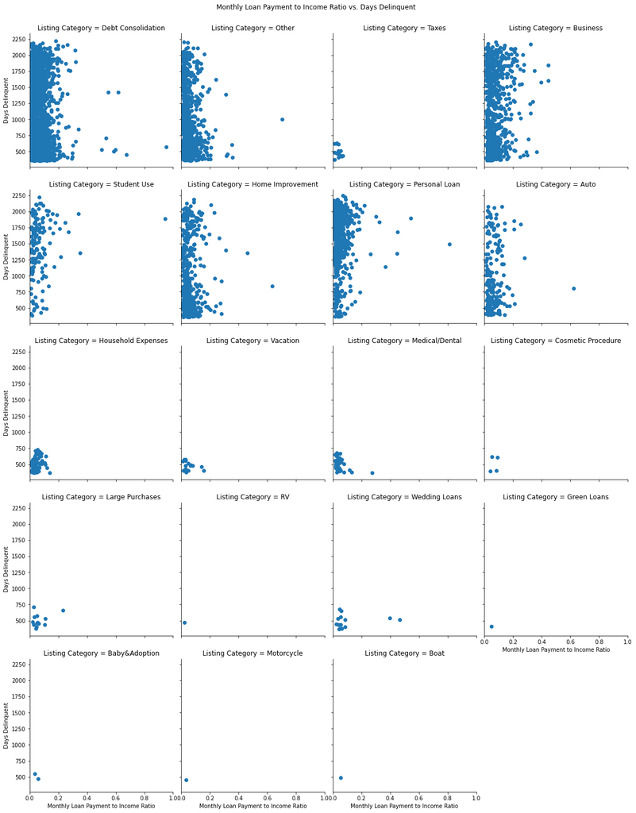

```python
#Plot MonthlyLoanPaymentDividedByMonthlyIncome vs LoanCurrentDaysDelinquent
g = sb.FacetGrid(data = temp_df, col = 'ListingCategory', height = 4, col_wrap = 4);
g.map(plt.scatter, 'MonthlyLoanPaymentDividedByMonthlyIncome', 'LoanCurrentDaysDelinquent');
plt.xlim(0,1);
# plt.legend()

for axe in g.axes:
    axe.set_title(axe.get_title().replace('ListingCategory', 'Listing Category'));

g.set_axis_labels(x_var="Monthly Loan Payment to Income Ratio", y_var="Days Delinquent");
plt.suptitle('Monthly Loan Payment to Income Ratio vs. Days Delinquent', y = 1.02);
```

> It seems there are some cases that their Loan Monthly payment is so much greater than their Monthly Income. (Validate this point: is that possible?)

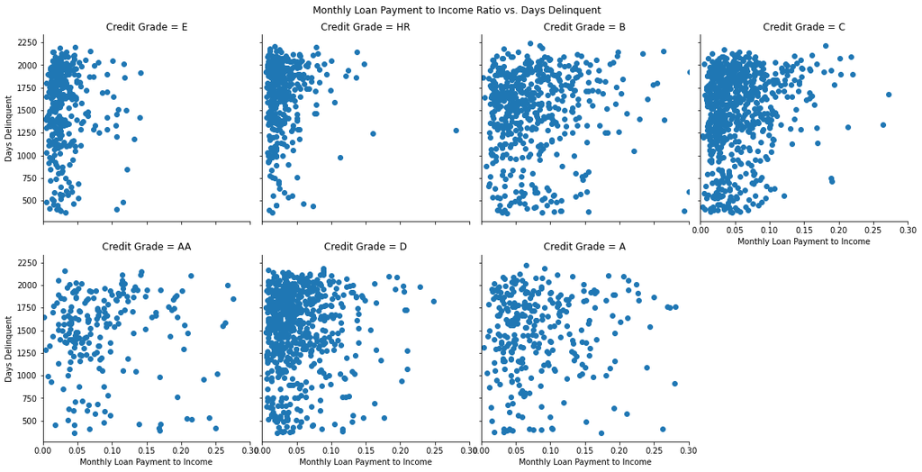

```python
#Plot MonthlyLoanPaymentDividedByMonthlyIncome vs LoanCurrentDaysDelinquent
g = sb.FacetGrid(data = temp_df, col = 'CreditGrade', height = 4, col_wrap = 4, margin_titles=True);
g.map(plt.scatter, 'MonthlyLoanPaymentDividedByMonthlyIncome', 'LoanCurrentDaysDelinquent');
plt.xlim(0,0.3);

for axe in g.axes:
    axe.set_title(axe.get_title().replace('CreditGrade', 'Credit Grade'));

g.set_axis_labels(x_var="Monthly Loan Payment to Income", y_var="Days Delinquent");
plt.suptitle('Monthly Loan Payment to Income Ratio vs. Days Delinquent', y = 1.02);
```

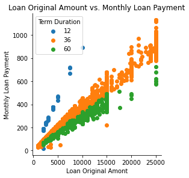

```python
g = sb.FacetGrid(data = temp_df, hue = 'Term' , height = 4);
g.map(plt.scatter,'LoanOriginalAmount', 'MonthlyLoanPayment');
plt.legend(title = 'Term Duration', loc = 'upper left');
plt.title('Loan Original Amount vs. Monthly Loan Payment');
plt.xlabel('Loan Original Amont');
plt.ylabel('Monthly Loan Payment');
```

The less the term duration is, the more monthly payment the borrowers have to pay.

### Relationship

> Borrower Interest rate is strongly correlated to the following:

> Lend Yield

> Estimated Effective Yield

> Estimated Loss

> Estimated Return

### Were there any interesting or surprising interactions between features?

> No